# Using data with functions

# Organizing your work

- Store function definition in **R** subdirectory
- Store Rmarkdown in different subdirectory (**Rmarkdown**)
- Set the scripts (**Rmarkdown**) as working directory
- Use **source** to read the functions into your working directory

```r
source("../R/power_gen.R")
power_gen
```

```
## function (height, flow, rho = 1000, g = 9.8, Keff = 0.8)
## {
##     result = rho * height * (flow) * g * Keff
##     return(result)
## }
```

# Generating Data for your function

You often want to apply your function to a range of data, that can come from

- files you read in to R (measured height and flow rate values)
- output from other functions/models
- data that you generate
  - sensitivity analysis
  - testing your model
  - stochastic models

# Random Numbers as Inputs

- sample from distributions (normal, uniform, poisson), which distribution depends on the model
- R has many tools for generating samples from distributions with known parameters (such as mean, standard deviation, or min/max)
  - generating rainfall for a hydrologic model given know mean and variance of rainfall
- R also has tools for picking samples from collections
  - generating fish catches based on populations for an economic model

  Others?

# Steps for running your model over multiple inputs

1. design a data structure to store results: sometimes this is automatic but not always
2. generate the input data
3. apply to the model

Example: Imagine we want to see how much power is generated given scenario where we know the mean and standard deviation of flow rates and heights for the reservoir, we want to compute the distribution of power by running our power_gen model

There are some useful R commands - there are many ways to do this, we will use commands from *purrr* library

We will start with * map_dfc (run a function over multiple inputs and return as a data frame (df), organized by column)

Lets say we know that heights come from a normal distribtuion with mean 10m and standard deviation of 1m And flow rates anywhere between 0.1 and 1

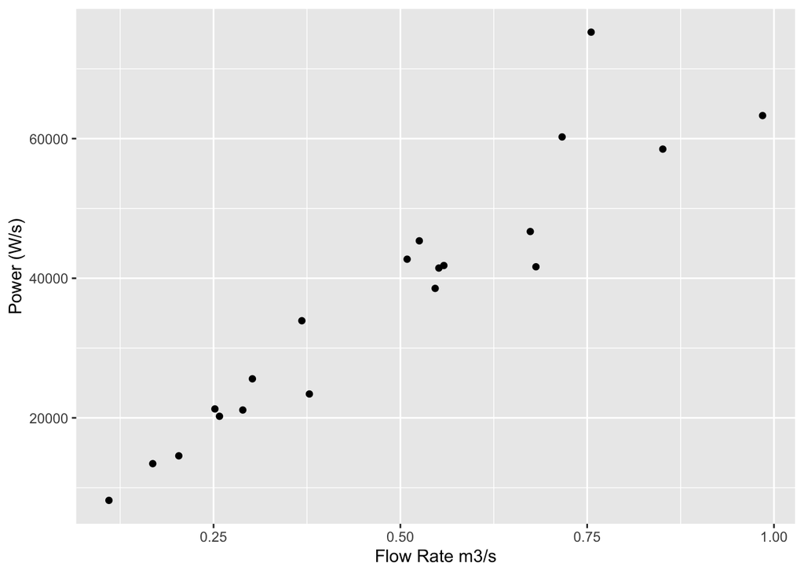

```r
# Step 1  create data frame to store results
# how many simulations
number_runs = 20

#create a dataframe that has rows for each model run
# columns for height, flow and power estimate
reservoir_model_res= as.data.frame(matrix(nrow=number_runs, ncol=2))
colnames(reservoir_model_res)=c("height","flow")


# STep 2 - generate heights and flow rates
reservoir_model_res$height = rnorm(mean=10, sd=1, n=number_runs)
reservoir_model_res$flow = runif(min=0.1, max=1, n=number_runs)

# Step 3 - apply model to get power for each height, flow rate - R will automatically do this IF function will be applied to each row of the data frame
reservoir_model_res = reservoir_model_res %>% mutate(Power=power_gen(height,flow))

# Always graph results to make sure they make sense
#View(reservoir_model_res)
ggplot(reservoir_model_res, aes(flow, Power))+geom_point()+labs(x="Flow Rate m3/s", y="Power (W/s)")
```

```r
# try this with different distributions for height and flow rate (different type of distribution), different parameters
```

# A more complex example

We might also want to compute for a range of efficiencies

This gets a bit more complicated - what if we want to look at our 20 samples of flow rate and height for EACH reservoir efficieny

We can use map_dfc - which applies the function over a sequence of data and returns a data frame organized by columns

Syntax is map_dfc(parameters you want to vary, function, other inputs and parameters)

See example below

```r
# create a sequence of efficienies
Keff = seq(from=0.1, to=0.5, by=0.1)
length(Keff)
```

```
## [1] 5
```

```r
# create a data structure - now we have to have one for each Keff

# use map_dfc to run for each value of Keff - where we get results for all heights and flow rates for each efficiency value


res = map_dfc(Keff, power_gen, height=reservoir_model_res$height, flow=reservoir_model_res$flow)
```

```
## * NA -> ...1
## * NA -> ...2
## * NA -> ...3
## * NA -> ...4
## * NA -> ...5
```

```r
head(res)
```

```
## # A tibble: 6 x 5
##    ...1  ...2  ...3  ...4  ...5
##   <dbl> <dbl> <dbl> <dbl> <dbl>
## 1 4.27   8.55 12.8  17.1  21.4
## 2 6.33  12.7  19.0  25.3  31.7
## 3 4.15   8.29 12.4  16.6  20.7
## 4 4.18   8.36 12.5  16.7  20.9
## 5 1.46   2.91  4.37  5.82  7.28
## 6 0.818  1.64  2.45  3.27  4.09
```

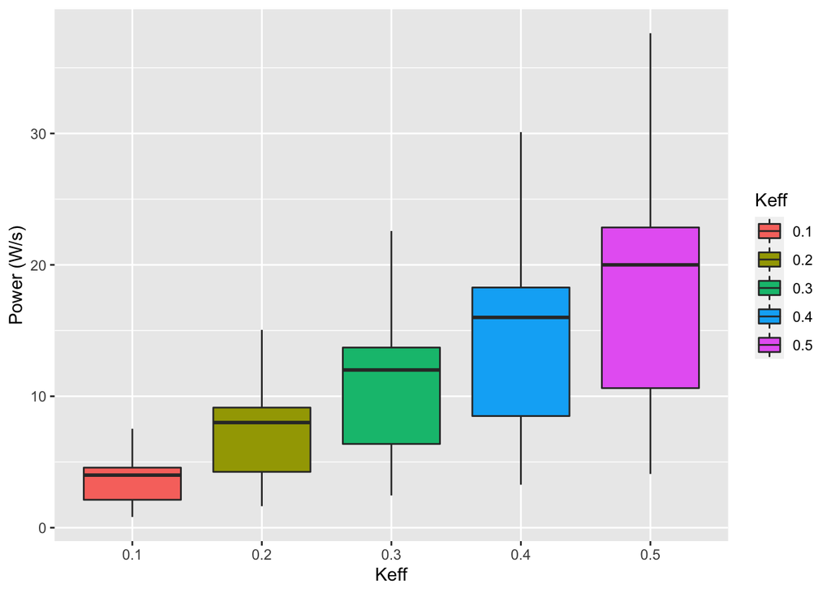

```r
# turn it into a data frame to support adding colums
colnames(res)=Keff

# rearrange to plot
resg=as.data.frame(res) %>% pivot_longer(everything(),names_to="Keff", values_to="Power")
ggplot(resg, aes(Keff, Power, fill=Keff))+geom_boxplot() + labs(y="Power (W/s)", "Efficiency")
```

```r
# do this yourself but expand the range of Keff to go up to 0.9
```

# Creating scenarios when you are varying many inputs and parameters

Often in running models - we have this situation where we are going to run across multiple inputs and parameters

Think creatively about data structures to store results

If there are too many dimensions (things that vary), it can be useful to define a scenario and give it a unique ID

There are some good R tools for this

** pivot_longer ** to collapse dimensions into labels and values ** inner_join ** to link datasets together by ID

In our case - in our res results - we don’t know what the “height” and “flow” rates were for each power output - so we can define a sceanrio id (scen) to keep track of all this

```r
head(reservoir_model_res)
```

```
##      height      flow     Power
## 1 10.706652 0.5090463 42729.424
## 2  8.199562 0.9847315 63303.039
## 3  9.589111 0.5514853 41459.906
## 4  9.556851 0.5581989 41823.451
## 5  9.127528 0.2034705 14560.312
## 6  9.484961 0.1099924  8179.266
```

```r
reservoir_model_res$scen= seq(from=1, to=nrow(reservoir_model_res))
res$scen = seq(from=1, to=nrow(reservoir_model_res))

head(reservoir_model_res)
```

```
##      height      flow     Power scen
## 1 10.706652 0.5090463 42729.424    1
## 2  8.199562 0.9847315 63303.039    2
## 3  9.589111 0.5514853 41459.906    3
## 4  9.556851 0.5581989 41823.451    4
## 5  9.127528 0.2034705 14560.312    5
## 6  9.484961 0.1099924  8179.266    6
```

```r
head(res)
```

```
## # A tibble: 6 x 6
##   `0.1` `0.2` `0.3` `0.4` `0.5`  scen
##   <dbl> <dbl> <dbl> <dbl> <dbl> <int>
## 1 4.27   8.55 12.8  17.1  21.4      1
## 2 6.33  12.7  19.0  25.3  31.7      2
## 3 4.15   8.29 12.4  16.6  20.7      3
## 4 4.18   8.36 12.5  16.7  20.9      4
## 5 1.46   2.91  4.37  5.82  7.28     5
## 6 0.818  1.64  2.45  3.27  4.09     6
```

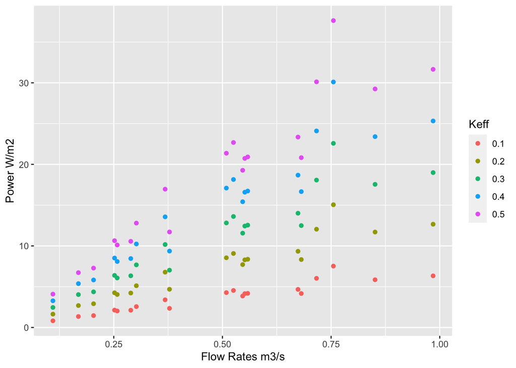

```r
# now combine into a long dataset
# the !scen means don't use it in the gathering

resg=as.data.frame(res) %>% pivot_longer(!scen,names_to="Keff", values_to="Power")

# now we can join with original reservoir results
# the original dataset had a default power column so we will add suffixes to account for that

# we use left_join and the resg as the left object because there are 'more' of them - one for each Keff
all_res = left_join(resg, reservoir_model_res, by="scen", suffix=c("",".default"))

# with this we can now plot power as a function of flow rate (what the operator would control) for all of our efficiencies and possible reservoir heights
ggplot(all_res, aes(flow, Power, col=Keff))+geom_point()+labs(x="Flow Rates m3/s", y="Power W/m2")
```

# Lists - For returning more than one item from your function

*Lists are the most “informal” data structures in R* List are really useful for keeping track of and organizing groups of things that are not all the same *A list could be a table where number of rows is different for each column* A list can have numeric, character, factors all mixed together * List are often used for returning more complex information from function (e.g. lm)

Here are some examples of how to create and manipulate lists

```r
# simple list
sale =  list(number=c(2,4,9), quality="high", what="apple", cost=4)
sale
```

```
## $number
## [1] 2 4 9
##
## $quality
## [1] "high"
##
## $what
## [1] "apple"
##
## $cost
## [1] 4
```

```r
sale$cost
```

```
## [1] 4
```

```r
sale$number
```

```
## [1] 2 4 9
```

```r
# 4th item in the list
sale[4]
```

```
## $cost
## [1] 4
```

# Lists are used to return multiple values from functions

**return(list(….))**

The function will return a list - you can always extract values from a list using its name

Here’s an example, what if what we want from our power_gen routine is actually the maximum , minimum and average power generation,

Here we will also use *map* from *purrr* to help us extract elements from a list once they come back from the function

```r
source("../R/power_gen_summary.R")

height = runif(min=0, max=100, n=100)
flow = runif(min=0, max=2, n=100)

power = power_gen_summary(height=height, flow=flow)
head(power)
```

```
## $max
## [1] 1557716
##
## $min
## [1] 270.5386
##
## $mean
## [1] 408452.2
```

```r
# try it yourself - try modifying power_gen_sumamry to also output the sum!

# lets now look at how summary varies with efficiency
Keff = seq(from=0.1, to=0.9, by=0.05)

# now we use a regular *map*
# we can't use map_df because our function now returns multiple items in a list
# so R can't so easily turn it into a data frame
# the basic *map* returns a list of lists!
res = map(Keff, power_gen_summary, height=reservoir_model_res$height, flow=reservoir_model_res$flow)

# res is now a list of list swith values of max, min and mean for each Keff
head(res)
```

```
## [[1]]
## [[1]]$max
## [1] 7.525458
##
## [[1]]$min
## [1] 0.8179266
##
## [[1]]$mean
## [1] 3.686479
##
##
## [[2]]
## [[2]]$max
## [1] 11.28819
##
## [[2]]$min
## [1] 1.22689
##
## [[2]]$mean
## [1] 5.529719
##
##
## [[3]]
## [[3]]$max
## [1] 15.05092
##
## [[3]]$min
## [1] 1.635853
##
## [[3]]$mean
## [1] 7.372958
##
##
## [[4]]
## [[4]]$max
## [1] 18.81365
##
## [[4]]$min
## [1] 2.044816
##
```

[output cut: 9 more lines]

```
## [1] 2.45378
##
## [[5]]$mean
## [1] 11.05944
##
##
## [[6]]
## [[6]]$max
## [1] 26.3391
##
## [[6]]$min
## [1] 2.862743
##
## [[6]]$mean
## [1] 12.90268
```

```r
#First list item is a list!
res[[1]]
```

```
## $max
## [1] 7.525458
##
## $min
## [1] 0.8179266
##
## $mean
## [1] 3.686479
```

```r
#To get second item in first list
res[[1]][[2]]
```

```
## [1] 0.8179266
```

```r
# not so easy but we can extract items from the list

# we can use map to extract named items from a list to a double (numeric)
map_dbl(res,"mean")
```

```
##  [1]  3.686479  5.529719  7.372958  9.216198 11.059438 12.902677 14.745917
##  [8] 16.589156 18.432396 20.275636 22.118875 23.962115 25.805354 27.648594
## [15] 29.491834 31.335073 33.178313
```

```r
map_dbl(res, "min")
```

```
##  [1] 0.8179266 1.2268899 1.6358532 2.0448165 2.4537798 2.8627431 3.2717064
##  [8] 3.6806697 4.0896330 4.4985963 4.9075596 5.3165229 5.7254861 6.1344494
## [15] 6.5434127 6.9523760 7.3613393
```

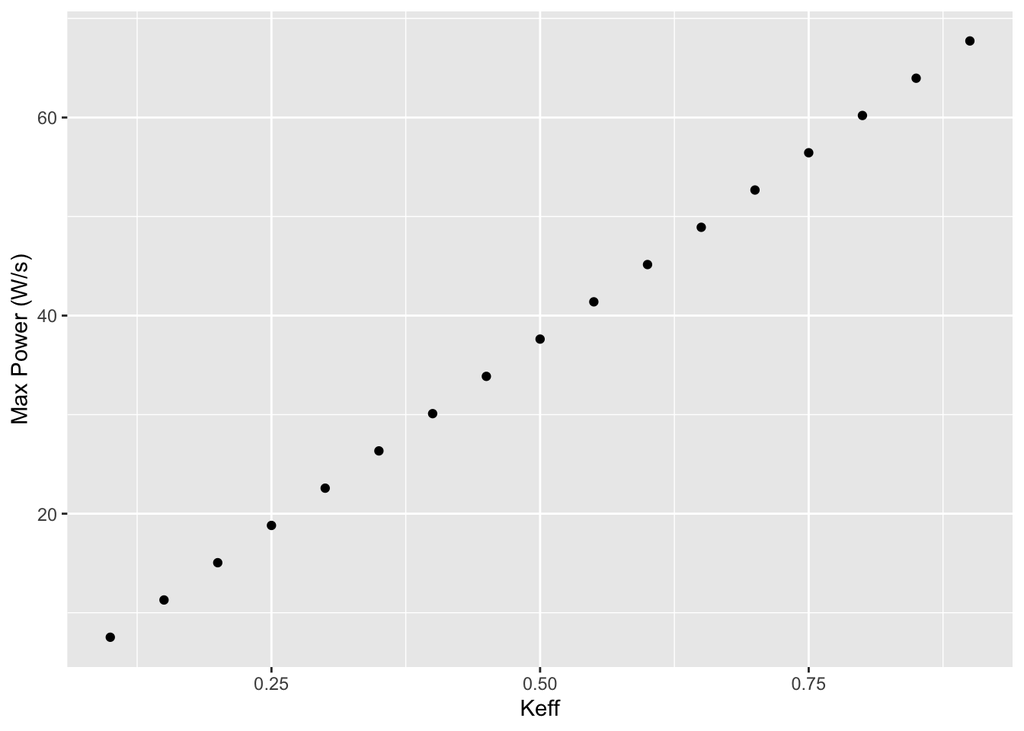

```r
# to get a data frame from list output, using different  names
resdf = map_dfr(res,`[`, c("mean","min","max"))

# add our Keff
resdf$Keff = Keff

# now we have a form that we can plot
ggplot(resdf, aes(Keff, max))+geom_point() + labs(y="Max Power (W/s)", "Efficiency")
```

```r
# try this if you modify the function to also output the total power
# try running with a different range of Keff
```